# The Grammar of Graphics

Arvind Venkatadri

06/July/2021

Abstract

Part of the `R for Artists and Designers` at the School of Foundation Studies, Srishti Manipal Institute of Art, Design, and Technology, Bangalore.

# 1 Introduction

This RMarkdown document is part of the Generic Skills Component (GSK) of the Course of the Foundation Studies Programme at Srishti Manipal Institute of Art, Design, and Technology, Bangalore India. The material is based on *A Layered Grammar of Graphics* by Hadley Wickham. The course is meant for First Year students pursuing a Degree in Art and Design.

The intent of this GSK part is to build Skill in coding in R, and also appreciate R as a way to metaphorically visualize information of various kinds, using predominantly geometric figures and structures.

All RMarkdown files combine code, text, web-images, and figures developed using code. Everything is text; code chunks are enclosed in **fences** (```)

# 2 Goals

At the end of this Lab session, we should: - know the types and structures of tidy data and be able to work with them - be able to create data visualizations using `ggplot` - Understand *aesthetics* and *scales* in `ggplot

# 3 Pedagogical Note

The method followed will be based on [PRIMM](https://blogs.kcl.ac.uk/cser/2017/09/01/primm-a-structured-approach-to-teaching-programming/):

- **PREDICT** Inspect the code and guess at what the code might do, **write predictions**
- **RUN** the code provided and check what happens
- **INFER** what the `parameters` of the code do and **write comments to explain**. What bells and whistles can you see?
- **MODIFY** the `parameters` code provided to understand the `options` available. **Write comments** to show what you have aimed for and achieved.
- **MAKE** : take an idea/concept of your own, and graph it.

## 3.1 Set Up

The `setup` code **chunk** below brings into our coding session **R packages** that provide specific computational abilities and also **datasets** which we can use.

To reiterate: Packages and datasets are **not** the same thing !! Packages are (small) collections of programs. Datasets are just….information.

# 4 A Teaser from John Snow

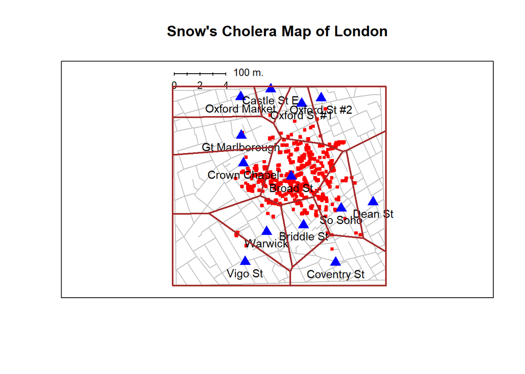

```r
SnowMap(polygons = TRUE)
```

```r
# Write some comments on this code and what it seems to be creating
# Are there "layers" in this visualization?







#
```

# 5 Tidy Data

“Tidy Data” is an important way of thinking about what data typically look like in R. Let’s fetch a figure from the web to show the (preferred) structure of data in R. (The syntax to bring in a web-figure is `![caption](url)`)

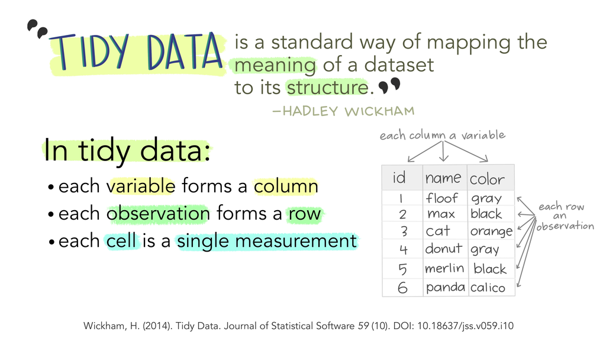

The three features described in the figure above define the nature of tidy data:

- *Variables in Columns*
- *Observations in Rows* and
- *Measurements in Cells*.

Data are imagined to be resulting from an **experiment**. Each *variable* represents a parameter/aspect in the experiment. Each *row* represents an additional datum of measurement. A *cell* is a single measurement on a single parameter(column) in a single observation(row).

## 5.1 Kinds of Variables

**Kinds of Variable** are defined by the kind of *questions* they answer to:

1. What/Who/Where? -> Some kind of Name. **Categorical** variable
2. What Kind? How? -> Some kind of “Type”. **Factor** variable
3. How Many? How large? -> Some kind of Quantity. **Numerical** variable. Most Figures in R are computed with variables, and therefore, with **columns**.

# 6 Interrogations and Graphs

Creating graphs from data is an act of asking questions and viewing answers in a geometric way. Let us write some simple English descriptions of measures and visuals and see what commands they use in R.

# 7 Components of the layered grammar of graphics

**Layers** are used to create the objects on a plot. They are defined by five basic parts:

1. Data (What dataset/spreadsheet am I using?)
2. Mapping (What does each column do in my graph?)
3. Statistical transformation (stat) (Do I have count something first?)
4. Geometric object (geom) (What shape, colour, size…do I want?)
5. Position adjustment (position) (Where do I want it on the graph?)

## 7.1 Data

We will use “real world” data. Let’s use the `penguins` dataset in the `palmerpenguins` package. Run `?penguins` in the console to get more information about this dataset.

### 7.1.1 Head

```r
head(penguins)
```

```
## # A tibble: 6 x 8
##   species island bill_length_mm bill_depth_mm flipper_length_~ body_mass_g sex
##   <fct>   <fct>           <dbl>         <dbl>            <int>       <int> <fct>
## 1 Adelie  Torge~           39.1          18.7              181        3750 male
## 2 Adelie  Torge~           39.5          17.4              186        3800 fema~
## 3 Adelie  Torge~           40.3          18                195        3250 fema~
## 4 Adelie  Torge~           NA            NA                 NA          NA <NA>
## 5 Adelie  Torge~           36.7          19.3              193        3450 fema~
## 6 Adelie  Torge~           39.3          20.6              190        3650 male
## # ... with 1 more variable: year <int>
```

### 7.1.2 Tail

```r
tail(penguins)
```

```
## # A tibble: 6 x 8
##   species island bill_length_mm bill_depth_mm flipper_length_~ body_mass_g sex
##   <fct>   <fct>           <dbl>         <dbl>            <int>       <int> <fct>
## 1 Chinst~ Dream            45.7          17                195        3650 fema~
## 2 Chinst~ Dream            55.8          19.8              207        4000 male
## 3 Chinst~ Dream            43.5          18.1              202        3400 fema~
## 4 Chinst~ Dream            49.6          18.2              193        3775 male
## 5 Chinst~ Dream            50.8          19                210        4100 male
## 6 Chinst~ Dream            50.2          18.7              198        3775 fema~
## # ... with 1 more variable: year <int>
```

### 7.1.3 Dim

```r
dim(penguins)
```

```
## [1] 344   8
```

So we know what our data looks like. We pass this data to `ggplot` use to plot as follows: in R this creates an empty graph sheet!! Because we have not (yet) declared the geometric shapes we want to use to plot our information.

```r
ggplot(data = penguins) # Creates an empty graphsheet, ready for plotting!!
```

## 7.2 Mapping

Now that we have told R what data to use, we need to state what variables to plot and how.

**Aesthetic Mapping** defines how the variables are applied to the plot, i.e. we take a variable from the data and “metaphorize” it into a geometric feature. We can map variables metaphorically to a variety of geometric things: coordinate, length, height, size, shape, colour, alpha(how dark?)….

The syntax uses: `aes(some_geometric_thing = some_variable)`

Remember **variable** = **column**.

So if we were graphing information from `penguins`, we might map a penguin’s `flipper_length_mm` **column** to the $x$ position, and the `body_mass_g` **column** to the $y$ position.

### 7.2.1 Mapping Example-1

We can try another example of aesthetic mapping with the same dataset:

#### 7.2.1.1 Plot-1a

```r
ggplot(data = penguins)
```

#### 7.2.1.2 Plot-1b

```
ggplot(penguins) +

# Plot geom = histogram. So we need a quantity on the x
  geom_histogram(
    aes(x = body_mass_g))
```

#### 7.2.1.3 Plot-1c

```
ggplot(penguins) +

# Plot geom = histogram. So we need a quantity on the x
  geom_histogram(
    aes(x = body_mass_g,
        fill = island)    # color aesthetic = another variable
    )
```

### 7.2.2 Mapping Example-2

We can try another example of aesthetic mapping with the same dataset:

#### 7.2.2.1 Plot-2a

```r
ggplot(data = penguins)
```

#### 7.2.2.2 Plot-2b

```
ggplot(penguins) +

# Plot geom = histogram. So we need a quantity on the x
  geom_histogram(
    aes(x = body_mass_g))
```

#### 7.2.2.3 Plot-2c

```
ggplot(penguins) +

# Plot geom = histogram. So we need a quantity on the x
  geom_histogram(
    aes(x = body_mass_g,
        fill = island)    # color aesthetic = another variable
    )
```

### 7.2.3 Mapping Example-3

We can try another example of aesthetic mapping with the same dataset:

#### 7.2.3.1 Plot-3a

```r
ggplot(data = penguins)
```

#### 7.2.3.2 Plot-3b

```
ggplot(penguins) +

# Plot geom = histogram. So we need a quantity on the x
  geom_histogram(
    aes(x = body_mass_g))
```

#### 7.2.3.3 Plot-3c

```
ggplot(penguins) +

# Plot geom = histogram. So we need a quantity on the x
  geom_histogram(
    aes(x = body_mass_g,
        fill = island)    # color aesthetic = another variable
    )
```

### 7.2.4 Mapping Example-4

We can try another example of aesthetic mapping with the same dataset:

#### 7.2.4.1 Plot-4a

```r
ggplot(data = penguins)
```

#### 7.2.4.2 Plot-4b

```
ggplot(penguins) +

# Plot geom = histogram. So we need a quantity on the x
  geom_histogram(
    aes(x = body_mass_g))
```

#### 7.2.4.3 Plot-4c

```
ggplot(penguins) +

# Plot geom = histogram. So we need a quantity on the x
  geom_histogram(
    aes(x = body_mass_g,
        fill = island)    # color aesthetic = another variable
    )
```

## 7.3 Geometric objects

**Geometric objects** (*geoms*) control the type of plot you create. Geoms are classified by their dimensionality:

- 0 dimensions - point, text
- 1 dimension - path, line
- 2 dimensions - polygon, interval

Each geom can only display certain **aesthetics** or visual attributes of the geom. For example, a point geom has position, color, shape, and size aesthetics.

We can also stack up geoms on top of one another to add layers to the graph.

### 7.3.1 Plot1

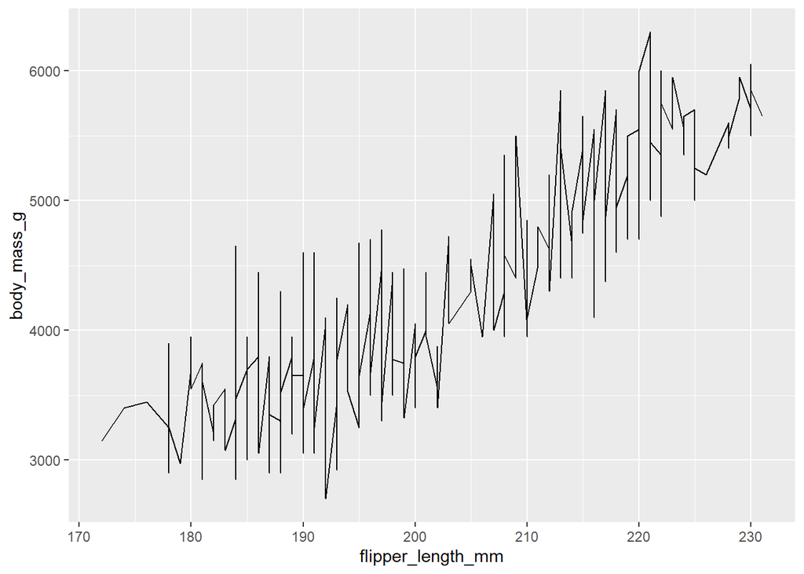

```r
ggplot(penguins, aes(x = flipper_length_mm, y = body_mass_g)) +
  geom_line()
```

### 7.3.2 Plot2

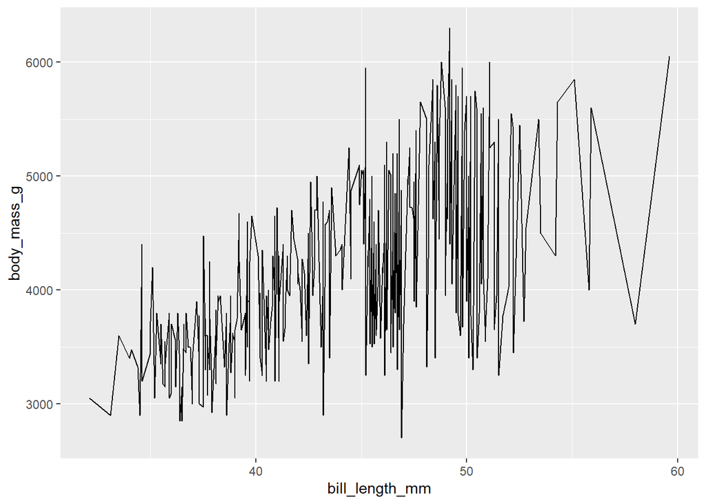

```r
ggplot(data = penguins) +
  geom_line(aes(x = bill_length_mm,
                     y = body_mass_g))
```

### 7.3.3 Plot3

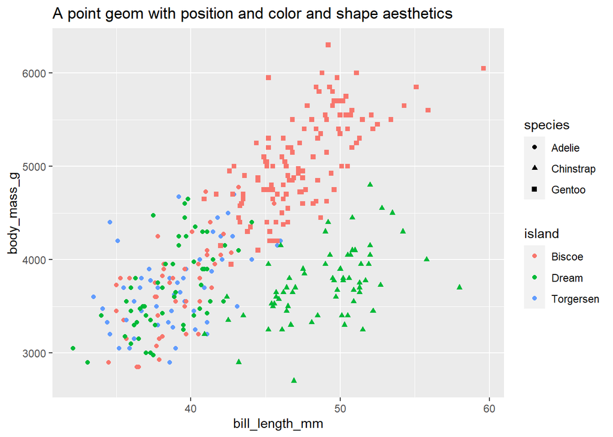

```r
ggplot(data = penguins) +
  geom_point(aes(x = bill_length_mm,
                     y = body_mass_g,
                 color = island,
                 shape = species)) +

  ggtitle("A point geom with position and color and shape aesthetics")
```

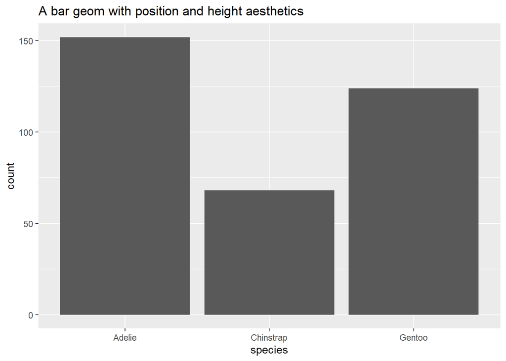

```r
ggplot(data = penguins,
       aes(x = species)) + # x position => ?
  # No need to type "mapping"...
  geom_bar() + # Where does the height come from?
  ggtitle("A bar geom with position and height aesthetics")
```

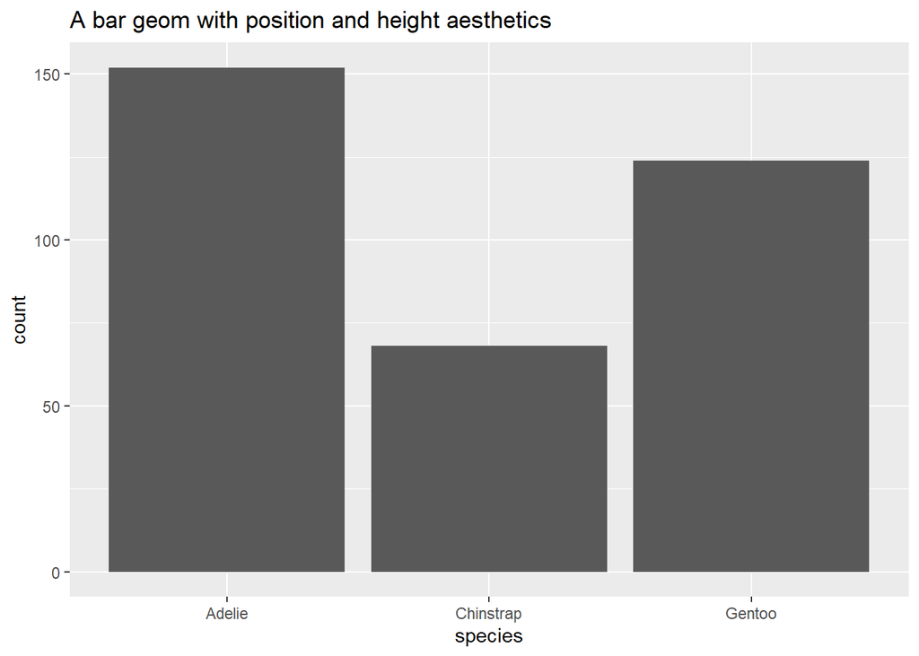

```r
ggplot(data = penguins, aes(x = species)) +
  geom_bar() +
  ggtitle("A bar geom with position and height aesthetics")
```

## 7.4 Position adjustment

Sometimes with dense data we need to adjust the position of elements on the plot, otherwise data points might obscure one another. Bar plots frequently **stack** or **dodge** the bars to avoid overlap:

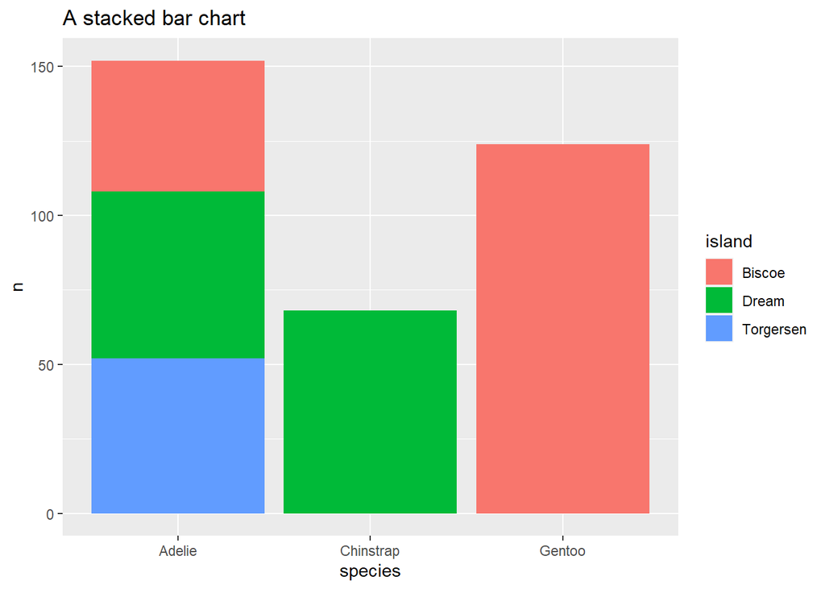

```r
count(x = penguins, species, island) %>%
  ggplot(mapping = aes(x = species, y = n, fill = island)) +
  geom_bar(stat = "identity") +
  ggtitle(label = "A stacked bar chart")
```

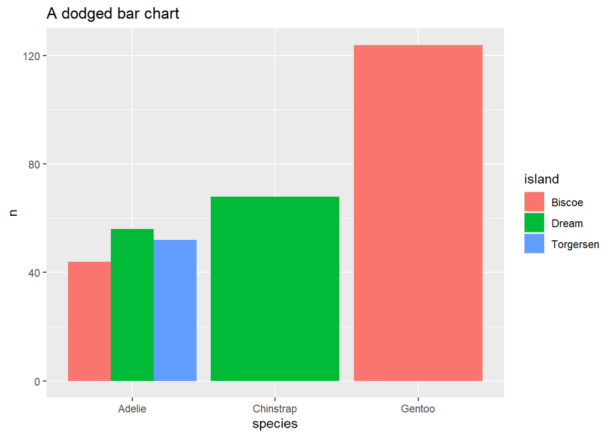

```r
count(x = penguins, species, island) %>%
  ggplot(mapping = aes(x = species, y = n, fill = island)) +
  geom_bar(stat = "identity", position = "dodge") +
  ggtitle(label = "A dodged bar chart")
```

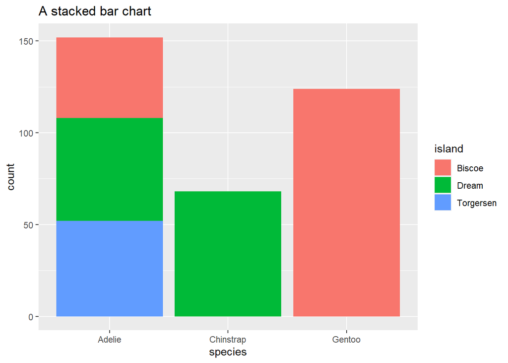

```r
penguins %>%
  ggplot(mapping = aes(x = species, fill = island)) +
  geom_bar() +
  ggtitle(label = "A stacked bar chart")
```

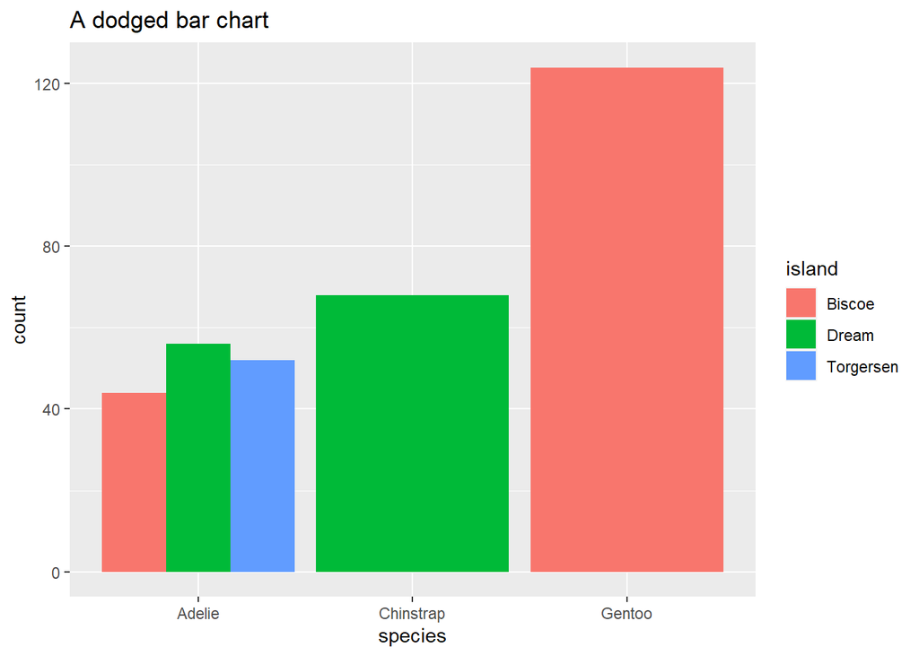

```r
penguins %>%
  ggplot(mapping = aes(x = species, fill = island)) +
  geom_bar(position = "dodge") +
  ggtitle(label = "A dodged bar chart")
```

Sometimes scatterplots with few unique $x$ and $y$ values are **jittered** (random noise is added) to reduce overplotting.

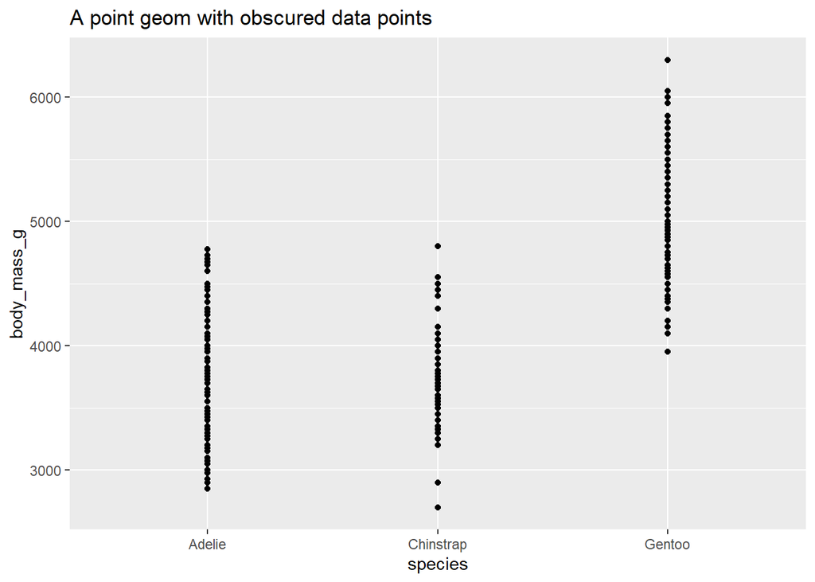

```r
ggplot(data = penguins,
       mapping = aes(x = species,
                     y = body_mass_g)) +
  geom_point() +
  ggtitle("A point geom with obscured data points")
```

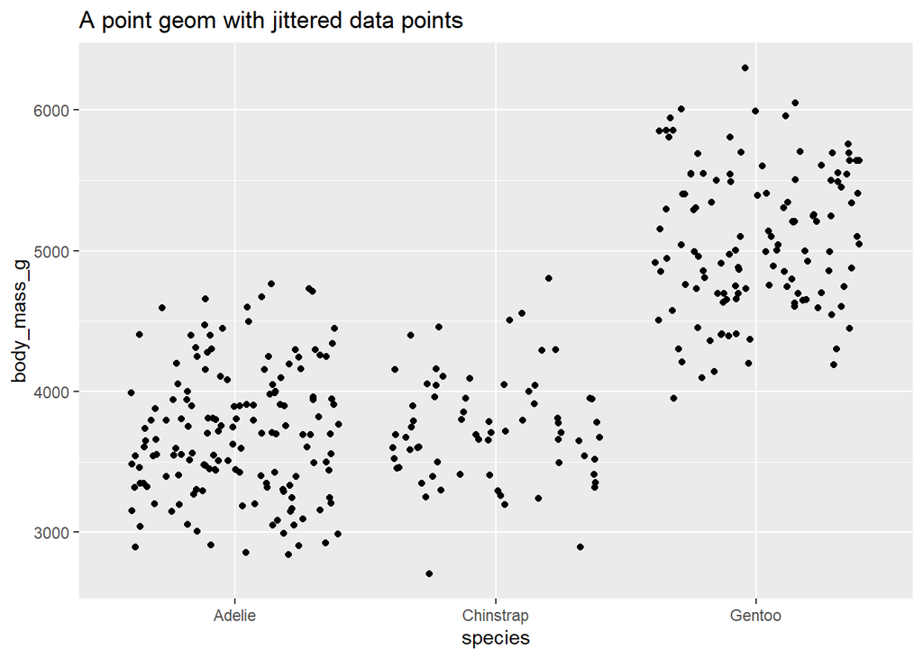

```r
ggplot(data = penguins,
       mapping = aes(x = species,
                     y = body_mass_g)) +
  geom_jitter() +
  ggtitle("A point geom with jittered data points")
```

## 7.5 Statistical transformation

A **statistical transformation** (*stat*) pre-transforms the data, before plotting. For instance, in a bar graph you might summarize the data by `count`ing the total number of observations within a set of categories, and then plotting the count.

### 7.5.1 Count

```r
count(x = penguins, island)
```

```
## # A tibble: 3 x 2
##   island        n
##   <fct>     <int>
## 1 Biscoe      168
## 2 Dream       124
## 3 Torgersen    52
```

### 7.5.2 Count and Bar Graph

```r
mydat <- count(penguins,island)

ggplot(data = mydat) +
    geom_col(aes(x = island, y = n))
```

### 7.5.3 Tidy Count and Bar Graph

```
penguins %>%           # This IS a pipe Operator!!

  count(., island) %>% # "." represents what is passed from the preceding command

  ggplot(.) +

  geom_col(aes(x = island, y = n))
```

### 7.5.4 Count inside the Plot

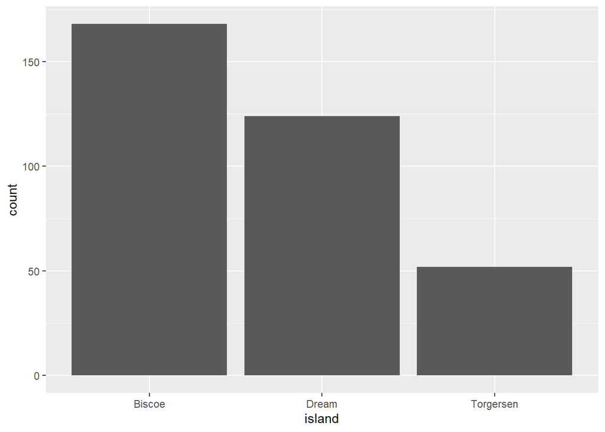

```r
penguins %>%           # Our pipe Operator

  ggplot(.) +          # "." becomes the penguins dataset

  geom_bar(aes(x = island)) # Note: y = count, and is computed internally!!
```

Sometimes you don’t need to make a statistical transformation. For example, in a scatterplot you use the raw values for the $x$ and $y$ variables to map onto the graph. In these situations, the statistical transformation is an *identity* transformation - the stat simply passes in the original dataset and exports the exact same dataset.

## 7.6 Scale

A **scale** controls how data is mapped to aesthetic attributes, so we need one scale for every aesthetic property employed in a layer. For example, this graph defines a scale for color:

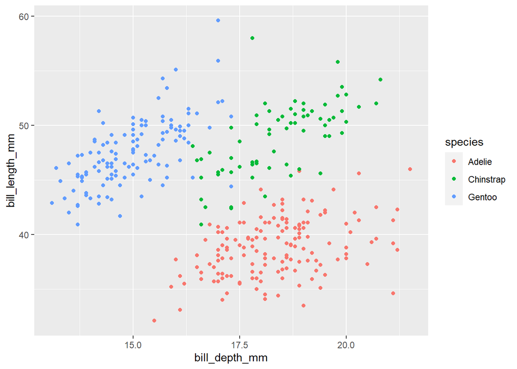

```r
ggplot(data = penguins,
       mapping = aes(x = bill_depth_mm,
                     y = bill_length_mm,
                     color = species)) +
  geom_point()
```

The scale can be changed to use a different color palette:

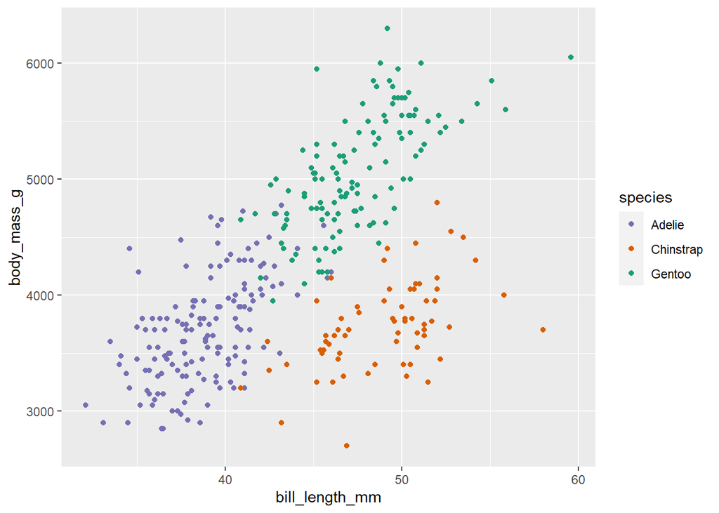

```r
ggplot(data = penguins,
       mapping = aes(x = bill_length_mm,
                     y = body_mass_g,
                     color = species)) +
  geom_point() +
  scale_color_brewer(palette = "Dark2",direction = -1)
```

Now we are using a different palette, but the scale is still consistent: all Adelie penguins utilize the same color, whereas Chinstrap use a new color **but each Adelie still uses the same, consistent color**.

## 7.7 Coordinate system

A **coordinate system** (*coord*) maps the position of objects onto the plane of the plot, and controls how the axes and grid lines are drawn. Plots typically use two coordinates ($x, y$), but could use any number of coordinates. Most plots are drawn using the [**Cartesian coordinate system**](https://en.wikipedia.org/wiki/Cartesian_coordinate_system):

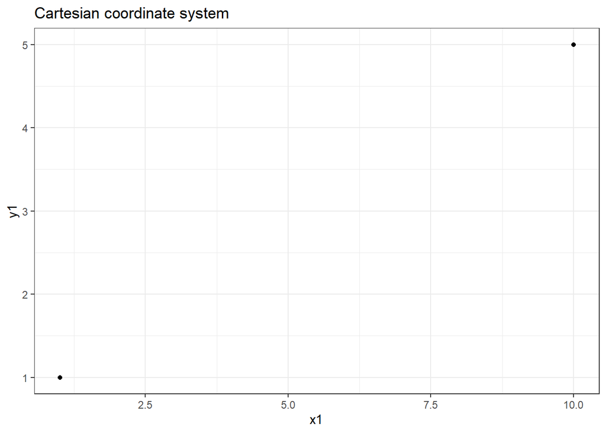

```r
x1 <- c(1, 10)
y1 <- c(1, 5)
p <- qplot(x = x1, y = y1, geom = "point", xlab = NULL, ylab = NULL) +
  theme_bw()
p +
  ggtitle(label = "Cartesian coordinate system")
```

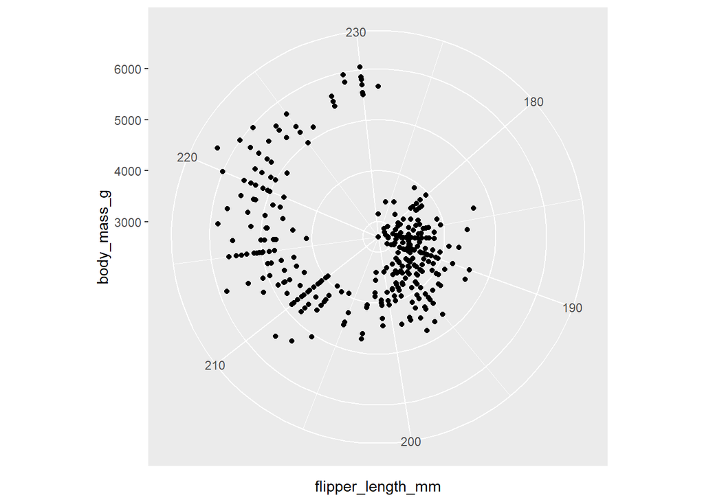

```r
ggplot(penguins, aes(flipper_length_mm, body_mass_g)) +
  geom_point() +
  coord_polar()
```

This system requires a fixed and equal spacing between values on the axes. That is, the graph draws the same distance between 1 and 2 as it does between 5 and 6. The graph could be drawn using a [**semi-log coordinate system**](https://en.wikipedia.org/wiki/Semi-log_plot) which logarithmically compresses the distance on an axis:

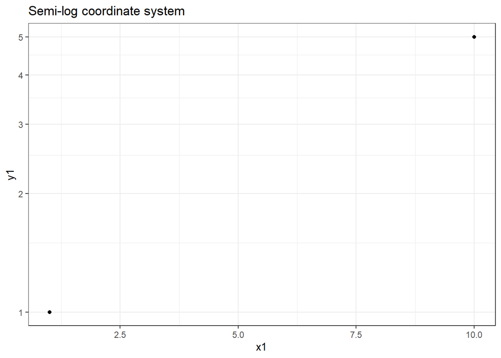

```r
p +
  coord_trans(y = "log10") +
  ggtitle(label = "Semi-log coordinate system")
```

Or could even be drawn using [**polar coordinates**](https://en.wikipedia.org/wiki/Polar_coordinate_system):

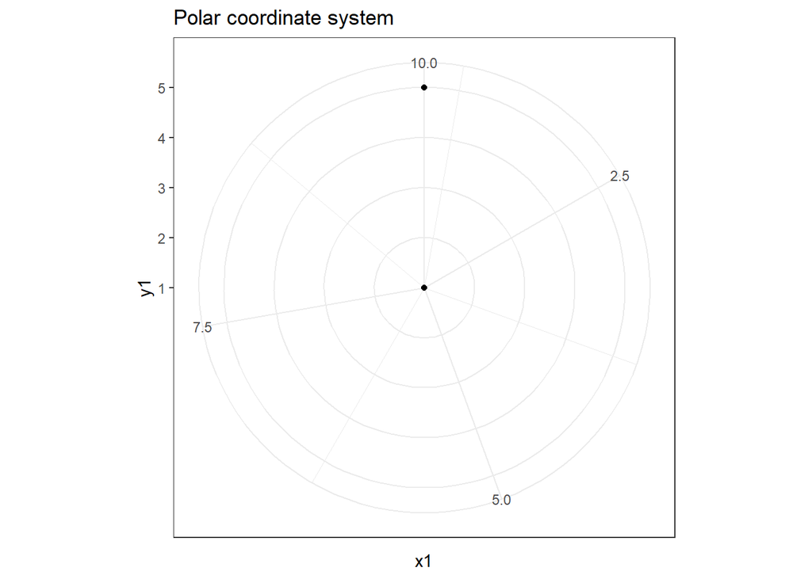

```r
p +
  coord_polar() +
  ggtitle(label = "Polar coordinate system")
```